# Project 1

Won Hee Kim

2022-12-03

## Data (Munging - EDA stage)

### Data inport/gathering

```r
online <- read.csv('OnlineNewsPopularity/OnlineNewsPopularity.csv')
data <- online
```

### Data summarization

```r
str(data)
```

```
## 'data.frame':    39644 obs. of  61 variables:
##  $ url                          : chr  "http://mashable.com/2013/01/07/amazon-instant-video-browser/" "http://mashable.com/2013/01/07/ap-samsung-sponsored-tweets/" "http://mashable.com/2013/01/07/apple-40-billion-app-downloads/" "http://mashable.com/2013/01/07/astronaut-notre-dame-bcs/" ...
##  $ timedelta                    : num  731 731 731 731 731 731 731 731 731 731 ...
##  $ n_tokens_title               : num  12 9 9 9 13 10 8 12 11 10 ...
##  $ n_tokens_content             : num  219 255 211 531 1072 ...
##  $ n_unique_tokens              : num  0.664 0.605 0.575 0.504 0.416 ...
##  $ n_non_stop_words             : num  1 1 1 1 1 ...
##  $ n_non_stop_unique_tokens     : num  0.815 0.792 0.664 0.666 0.541 ...
##  $ num_hrefs                    : num  4 3 3 9 19 2 21 20 2 4 ...
##  $ num_self_hrefs               : num  2 1 1 0 19 2 20 20 0 1 ...
##  $ num_imgs                     : num  1 1 1 1 20 0 20 20 0 1 ...
##  $ num_videos                   : num  0 0 0 0 0 0 0 0 0 1 ...
##  $ average_token_length         : num  4.68 4.91 4.39 4.4 4.68 ...
##  $ num_keywords                 : num  5 4 6 7 7 9 10 9 7 5 ...
##  $ data_channel_is_lifestyle    : num  0 0 0 0 0 0 1 0 0 0 ...
```

[output cut: 47 more lines]

```r
summary(data)
```

```
##      url              timedelta     n_tokens_title n_tokens_content
##  Length:39644       Min.   :  8.0   Min.   : 2.0   Min.   :   0.0
##  Class :character   1st Qu.:164.0   1st Qu.: 9.0   1st Qu.: 246.0
##  Mode  :character   Median :339.0   Median :10.0   Median : 409.0
##                     Mean   :354.5   Mean   :10.4   Mean   : 546.5
##                     3rd Qu.:542.0   3rd Qu.:12.0   3rd Qu.: 716.0
##                     Max.   :731.0   Max.   :23.0   Max.   :8474.0
##  n_unique_tokens    n_non_stop_words    n_non_stop_unique_tokens
##  Min.   :  0.0000   Min.   :   0.0000   Min.   :  0.0000
##  1st Qu.:  0.4709   1st Qu.:   1.0000   1st Qu.:  0.6257
##  Median :  0.5392   Median :   1.0000   Median :  0.6905
##  Mean   :  0.5482   Mean   :   0.9965   Mean   :  0.6892
##  3rd Qu.:  0.6087   3rd Qu.:   1.0000   3rd Qu.:  0.7546
##  Max.   :701.0000   Max.   :1042.0000   Max.   :650.0000
##    num_hrefs      num_self_hrefs       num_imgs         num_videos
##  Min.   :  0.00   Min.   :  0.000   Min.   :  0.000   Min.   : 0.00
##  1st Qu.:  4.00   1st Qu.:  1.000   1st Qu.:  1.000   1st Qu.: 0.00
##  Median :  8.00   Median :  3.000   Median :  1.000   Median : 0.00
##  Mean   : 10.88   Mean   :  3.294   Mean   :  4.544   Mean   : 1.25
##  3rd Qu.: 14.00   3rd Qu.:  4.000   3rd Qu.:  4.000   3rd Qu.: 1.00
##  Max.   :304.00   Max.   :116.000   Max.   :128.000   Max.   :91.00
##  average_token_length  num_keywords    data_channel_is_lifestyle
##  Min.   :0.000        Min.   : 1.000   Min.   :0.00000
##  1st Qu.:4.478        1st Qu.: 6.000   1st Qu.:0.00000
##  Median :4.664        Median : 7.000   Median :0.00000
##  Mean   :4.548        Mean   : 7.224   Mean   :0.05295
##  3rd Qu.:4.855        3rd Qu.: 9.000   3rd Qu.:0.00000
##  Max.   :8.042        Max.   :10.000   Max.   :1.00000
##  data_channel_is_entertainment data_channel_is_bus data_channel_is_socmed
##  Min.   :0.000                 Min.   :0.0000      Min.   :0.0000
##  1st Qu.:0.000                 1st Qu.:0.0000      1st Qu.:0.0000
##  Median :0.000                 Median :0.0000      Median :0.0000
##  Mean   :0.178                 Mean   :0.1579      Mean   :0.0586
##  3rd Qu.:0.000                 3rd Qu.:0.0000      3rd Qu.:0.0000
##  Max.   :1.000                 Max.   :1.0000      Max.   :1.0000
##  data_channel_is_tech data_channel_is_world   kw_min_min       kw_max_min
##  Min.   :0.0000       Min.   :0.0000        Min.   : -1.00   Min.   :     0
##  1st Qu.:0.0000       1st Qu.:0.0000        1st Qu.: -1.00   1st Qu.:   445
##  Median :0.0000       Median :0.0000        Median : -1.00   Median :   660
##  Mean   :0.1853       Mean   :0.2126        Mean   : 26.11   Mean   :  1154
```

[output cut: 71 more lines]

```
##  Max.   : 0.0000       Max.   : 0.0000       Max.   : 0.0000
##  title_subjectivity title_sentiment_polarity abs_title_subjectivity
##  Min.   :0.0000     Min.   :-1.00000         Min.   :0.0000
##  1st Qu.:0.0000     1st Qu.: 0.00000         1st Qu.:0.1667
##  Median :0.1500     Median : 0.00000         Median :0.5000
##  Mean   :0.2824     Mean   : 0.07143         Mean   :0.3418
##  3rd Qu.:0.5000     3rd Qu.: 0.15000         3rd Qu.:0.5000
##  Max.   :1.0000     Max.   : 1.00000         Max.   :0.5000
##  abs_title_sentiment_polarity     shares
##  Min.   :0.0000               Min.   :     1
##  1st Qu.:0.0000               1st Qu.:   946
##  Median :0.0000               Median :  1400
##  Mean   :0.1561               Mean   :  3395
##  3rd Qu.:0.2500               3rd Qu.:  2800
##  Max.   :1.0000               Max.   :843300
```

### Data visualization

The variables for the Mashable data channel (article category), the day the article was published, and whether it was published on a weekend are changed from numeric to factor variables. Variables which do not listed below will be discussed in the process of analyzing the data.

```r
# data_channel
online[,14:19] <- lapply(online[,14:19], as.factor)

# weekday
online[,32:39] <- lapply(online[,32:39], as.factor)
```

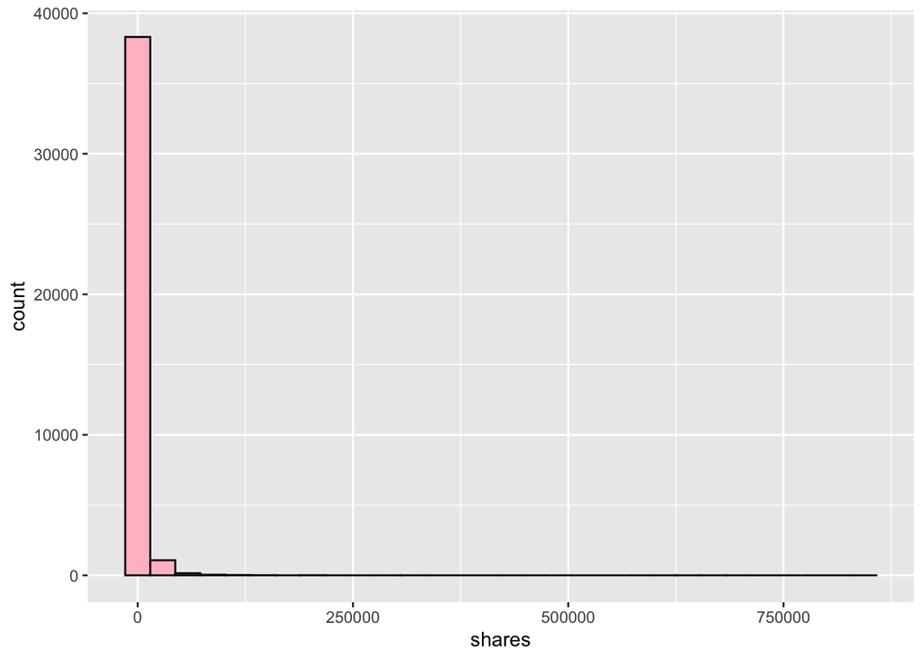

```r
{ ggplot(online, aes(x = shares)) +
  geom_histogram(fill = "pink", color = "black")
}
```

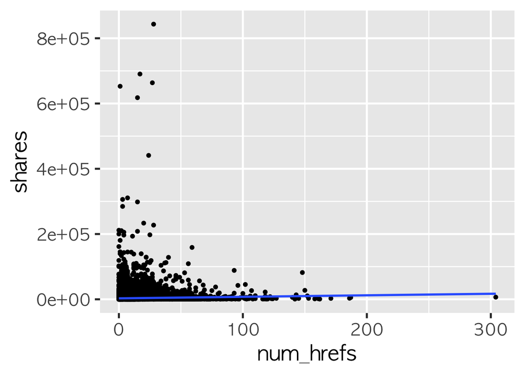

```r
{ ggplot(online, aes(x=num_hrefs, y=shares)) +
  geom_point() + geom_smooth(method=lm) +
  theme_gray(base_family = 'AppleGothic', base_size = 20)
}
```

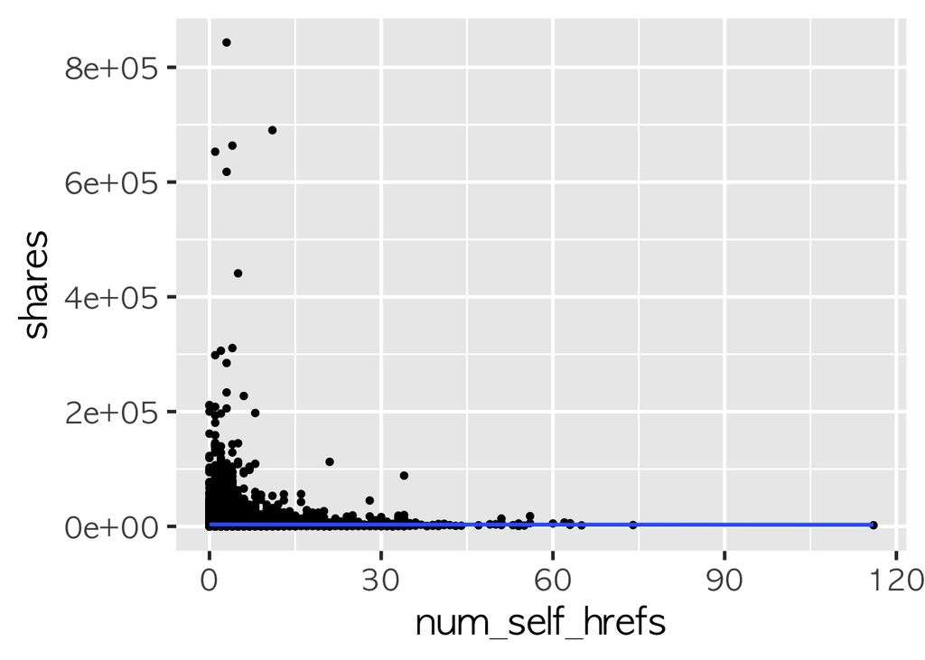

```r
{ ggplot(online, aes(x=num_self_hrefs, y=shares)) +
  geom_point() + geom_smooth(method=lm) +
  theme_gray(base_family = 'AppleGothic', base_size = 20)
}
```

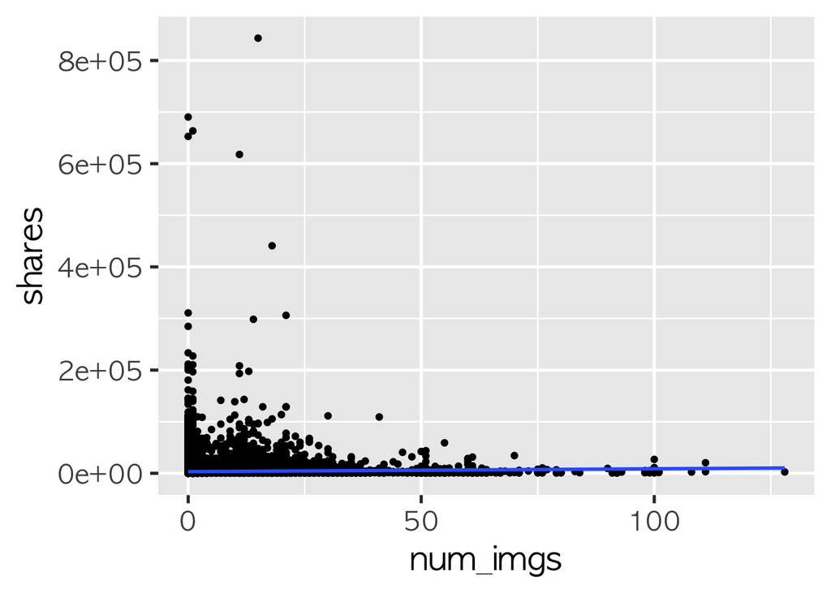

```r
{ ggplot(online, aes(x=num_imgs, y=shares)) +
  geom_point() + geom_smooth(method=lm) +
  theme_gray(base_family = 'AppleGothic', base_size = 20)
}
```

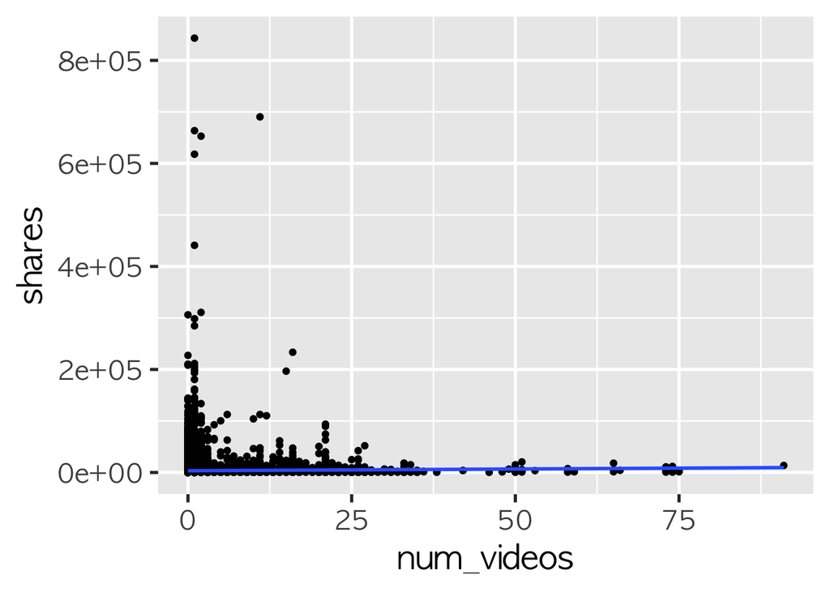

```r
{ ggplot(online, aes(x=num_videos, y=shares)) +
  geom_point() + geom_smooth(method=lm) +
  theme_gray(base_family = 'AppleGothic', base_size = 20)
}
```

```r
# -> categorical / channel
channel_X <- c("lifestyle", "entertainment", "bus", "socmed", "tech", "world", "else")
channel_count <- c(table(online$data_channel_is_lifestyle)[2], table(online$data_channel_is_entertainment)[2],
                   table(online$data_channel_is_bus)[2], table(online$data_channel_is_socmed)[2],
                   table(online$data_channel_is_tech)[2], table(online$data_channel_is_world)[2], 900)
channel_pct <- c(round((table(online$data_channel_is_lifestyle)[2]/nrow(online))*100,2),
                 round((table(online$data_channel_is_entertainment)[2]/nrow(online))*100,2),
                 round((table(online$data_channel_is_bus)[2]/nrow(online))*100,2),
                 round((table(online$data_channel_is_socmed)[2]/nrow(online))*100,2),
                 round((table(online$data_channel_is_tech)[2]/nrow(online))*100,2),
                 round((table(online$data_channel_is_world)[2]/nrow(online))*100,2),
                 round((900/nrow(online))*100,2))
channel <- data.frame(channel_X, channel_count, channel_pct)
channel
```

| channel_X | channel_count | channel_pct |
| --- | --- | --- |
| lifestyle | 2099 | 5.29 |
| entertainment | 7057 | 17.80 |
| bus | 6258 | 15.79 |
| socmed | 2323 | 5.86 |
| tech | 7346 | 18.53 |
| world | 8427 | 21.26 |
| else | 900 | 2.27 |

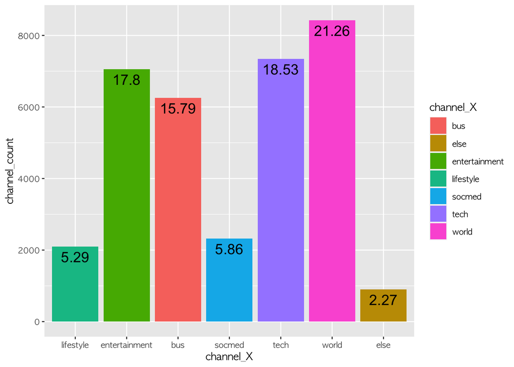

```r
{ ggplot(channel, aes(x = channel_X, y = channel_count, fill = channel_X)) +  geom_bar(stat = "identity") +
  geom_text(aes(label=channel_pct), position = position_dodge(0.9), vjust = 1.5, color = "black", size = 5) +
  scale_x_discrete(limits = channel$channel_X) +
  theme_gray(base_family = 'AppleGothic', base_size = 10)
}
```

```r
# -> categorical / weekday
weekday_X <- c("Mon", "Tue", "Wed", "Thu", "Fri", "Sat", "Sun")
weekday_count <- c(table(online$weekday_is_monday)[2], table(online$weekday_is_tuesday)[2],
                   table(online$weekday_is_wednesday)[2], table(online$weekday_is_thursday)[2],
                   table(online$weekday_is_friday)[2], table(online$weekday_is_saturday)[2],
                   table(online$weekday_is_sunday)[2])
weekday_pct <- c(round((table(online$weekday_is_monday)[2]/nrow(online))*100,2),
                 round((table(online$weekday_is_tuesday)[2]/nrow(online))*100,2),
                 round((table(online$weekday_is_wednesday)[2]/nrow(online))*100,2),
                 round((table(online$weekday_is_thursday)[2]/nrow(online))*100,2),
                 round((table(online$weekday_is_friday)[2]/nrow(online))*100,2),
                 round((table(online$weekday_is_saturday)[2]/nrow(online))*100,2),
                 round((table(online$weekday_is_sunday)[2]/nrow(online))*100,2))
weekday <- data.frame(weekday_X, weekday_count, weekday_pct)
weekday
```

| weekday_X | weekday_count | weekday_pct |
| --- | --- | --- |
| Mon | 6661 | 16.80 |
| Tue | 7390 | 18.64 |
| Wed | 7435 | 18.75 |
| Thu | 7267 | 18.33 |
| Fri | 5701 | 14.38 |
| Sat | 2453 | 6.19 |
| Sun | 2737 | 6.90 |

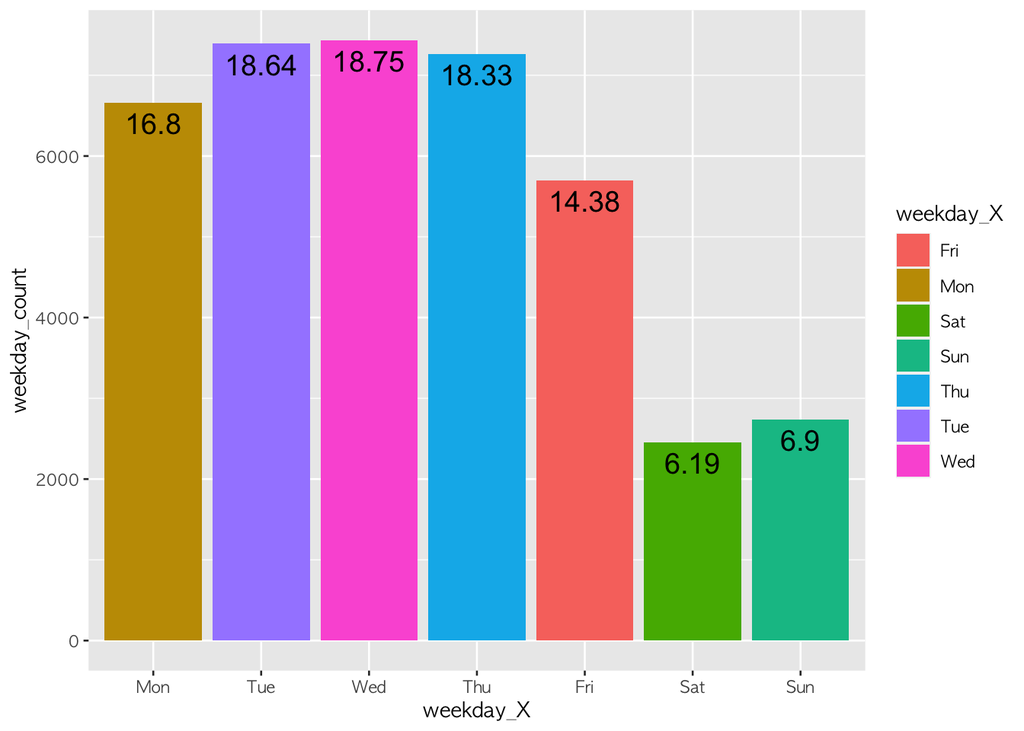

```r
{ ggplot(weekday, aes(x = weekday_X, y = weekday_count, fill = weekday_X)) +  geom_bar(stat = "identity") +
  geom_text(aes(label=weekday_pct), position = position_dodge(0.9), vjust = 1.5, color = "black", size = 5) +
  scale_x_discrete(limits = weekday$weekday_X) +
  theme_gray(base_family = 'AppleGothic', base_size = 10)
  }
```

```r
# -> categorical / weekend
weekend_X <- c("Yes", "No")
weekend_count <- c(table(online$is_weekend)[2], table(online$is_weekend)[1])
weekend_pct <- c(round((table(online$is_weekend)[2]/nrow(online))*100,2),
                 round((table(online$is_weekend)[1]/nrow(online))*100,2))
weekend <- data.frame(weekend_X, weekend_count, weekend_pct)
weekend
```

|  | weekend_X | weekend_count | weekend_pct |
| --- | --- | --- | --- |
| 1 | Yes | 5190 | 13.09 |
| 0 | No | 34454 | 86.91 |

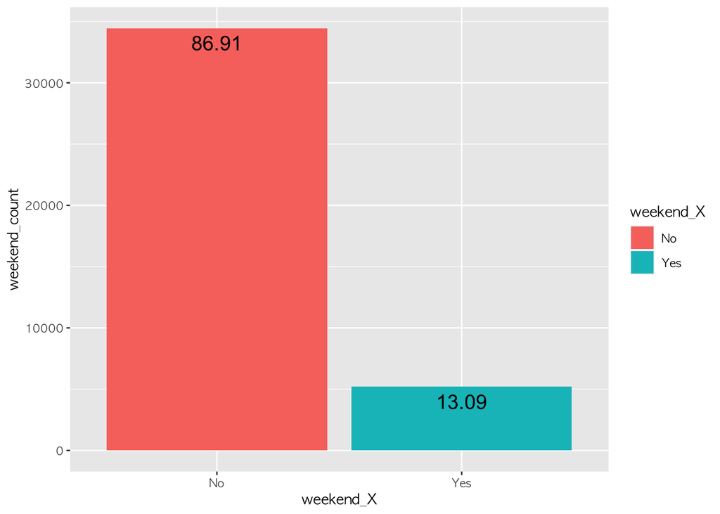

```r
{ ggplot(weekend, aes(x = weekend_X, y = weekend_count, fill = weekend_X)) +  geom_bar(stat = "identity") +
  geom_text(aes(label=weekend_pct), position = position_dodge(0.9), vjust = 1.5, color = "black", size = 5) +
  scale_x_discrete(limits = weekday$weekend_X) +
  theme_gray(base_family = 'AppleGothic', base_size = 10)
  }
```

### Data preparation (tidying/engineering)

First, it is confirmed that there is no missing values as shown below.

```r
sapply(data, function(x) ifelse(sum(is.na(x)) == 0, "No", "Yes"))
```

```
##                           url                     timedelta
##                          "No"                          "No"
##                n_tokens_title              n_tokens_content
##                          "No"                          "No"
##               n_unique_tokens              n_non_stop_words
##                          "No"                          "No"
##      n_non_stop_unique_tokens                     num_hrefs
##                          "No"                          "No"
##                num_self_hrefs                      num_imgs
##                          "No"                          "No"
##                    num_videos          average_token_length
##                          "No"                          "No"
##                  num_keywords     data_channel_is_lifestyle
##                          "No"                          "No"
## data_channel_is_entertainment           data_channel_is_bus
##                          "No"                          "No"
##        data_channel_is_socmed          data_channel_is_tech
##                          "No"                          "No"
##         data_channel_is_world                    kw_min_min
##                          "No"                          "No"
##                    kw_max_min                    kw_avg_min
##                          "No"                          "No"
##                    kw_min_max                    kw_max_max
##                          "No"                          "No"
##                    kw_avg_max                    kw_min_avg
##                          "No"                          "No"
##                    kw_max_avg                    kw_avg_avg
##                          "No"                          "No"
##     self_reference_min_shares     self_reference_max_shares
##                          "No"                          "No"
##    self_reference_avg_sharess             weekday_is_monday
##                          "No"                          "No"
##            weekday_is_tuesday          weekday_is_wednesday
##                          "No"                          "No"
##           weekday_is_thursday             weekday_is_friday
##                          "No"                          "No"
##           weekday_is_saturday             weekday_is_sunday
##                          "No"                          "No"
##                    is_weekend                        LDA_00
##                          "No"                          "No"
##                        LDA_01                        LDA_02
##                          "No"                          "No"
##                        LDA_03                        LDA_04
##                          "No"                          "No"
##           global_subjectivity     global_sentiment_polarity
##                          "No"                          "No"
##    global_rate_positive_words    global_rate_negative_words
##                          "No"                          "No"
##           rate_positive_words           rate_negative_words
##                          "No"                          "No"
##         avg_positive_polarity         min_positive_polarity
##                          "No"                          "No"
##         max_positive_polarity         avg_negative_polarity
##                          "No"                          "No"
##         min_negative_polarity         max_negative_polarity
##                          "No"                          "No"
##            title_subjectivity      title_sentiment_polarity
##                          "No"                          "No"
##        abs_title_subjectivity  abs_title_sentiment_polarity
##                          "No"                          "No"
##                        shares
##                          "No"
```

#### transformations - center/scale - dummy variables

Based on the five continuous variables(LDA_00/01/02/03/04), a dummy variable, which is LDA_Topic, is created and it is a categorical variable. The variable of LDA_Topic is about the nearest LDA Topic that is related to LDA_00/01/02/03/04. Also, it show the visualization about the proportion of LDA Topic.

```r
########################## dummy variable - LDA Topic ##########################
LDA_Topic <- c()
for (i in 1:nrow(online)) {
  LDA_Topic[i] <- which.max(online[i, c(40:44)])
}
online <- cbind(online, LDA_Topic)
online$LDA_Topic <- as.factor(online$LDA_Topic)

levels(online$LDA_Topic) <- c("Topic0","Topic1","Topic2","Topic3","Topic4")

tbl = table(online$LDA_Topic)
tbl_cnt = data.frame(cbind(freq = tbl))
tbl_cnt$LDA_Topic = row.names(tbl_cnt)
row.names(tbl_cnt) = NULL
name <- names(table(online$LDA_Topic))
tbl = within(tbl_cnt, {pct = paste(round((freq / sum(freq))*100, 1), "%", sep="")})
tbl
```

| freq | LDA_Topic | pct |
| --- | --- | --- |
| 7393 | Topic0 | 18.6% |
| 4759 | Topic1 | 12% |
| 8617 | Topic2 | 21.7% |
| 9290 | Topic3 | 23.4% |
| 9585 | Topic4 | 24.2% |

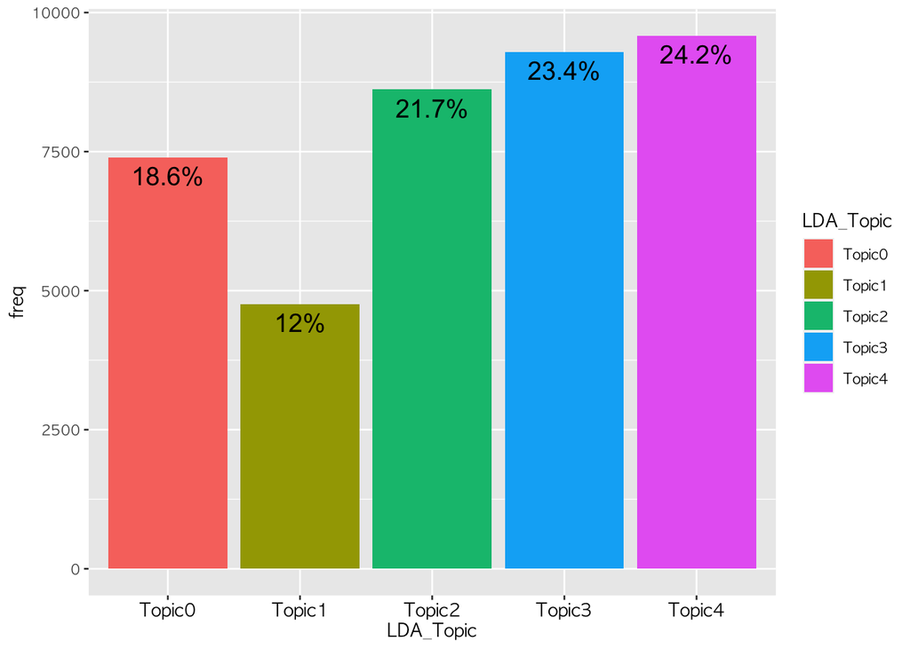

```r
{ ggplot(tbl, aes(x = LDA_Topic, y = freq, fill= LDA_Topic)) +  geom_bar(stat='identity') +
  geom_text(aes(label=pct), position = position_dodge(0.9), vjust = 1.5, color = "black", size = 5) +
  scale_x_discrete(limits = name) +
  theme_gray(base_family = 'AppleGothic', base_size = 10) %+replace%
  theme(axis.text.x = element_text(size = 10, color = "black"))
}
```

Now, let’s talk about outliers. Since the variables of ‘kw_min_min’, ‘kw_avg_min’ and ‘kw_min_avg’ are related to the number of shares, they cannot be less than 0. However, if you check the table below, you can see that the minimum value is less than zero. Therefore, values less than 0 were replaced with 0. (‘kw_min_min’: 22980, ‘kw_avg_min’: 833, ‘kw_min_avg’: 6)

```r
################################### Outliers ###################################
underZero <- matrix(NA, nrow = 1, ncol = 9)
for (i in 1:9) {
  underZero[i] <- length(which(online[i+19] < 0))
}
colnames(underZero) <- c(names(online)[20:28])
rownames(underZero) <- c('count')
underZero
```

```
##       kw_min_min kw_max_min kw_avg_min kw_min_max kw_max_max kw_avg_max
## count      22980          0        833          0          0          0
##       kw_min_avg kw_max_avg kw_avg_avg
## count          6          0          0
```

```r
online[online$kw_min_min < 0, "kw_min_min"] = 0
online[online$kw_avg_min < 0, "kw_avg_min"] = 0
online[online$kw_min_avg < 0, "kw_min_avg"] = 0
```

Now, we check the variable of ‘n_tokens_content’ regarding with the number of words in the content. If ‘n_tokens_content’ is 0, it means that no text is written in the article. However, it is thought that the lack of words in the article is an error during the web mining process, so observations (1181) with n_tokens_content of 0 is removed. As shown below, it can be confirmed that the overall distribution does not change even if 1181 data items are removed from the original data.

```r
# n_tokens_content / n_tokens_unique_tokens / ...
nrow(online[online$n_tokens_content == 0,])
```

```
## [1] 1181
```

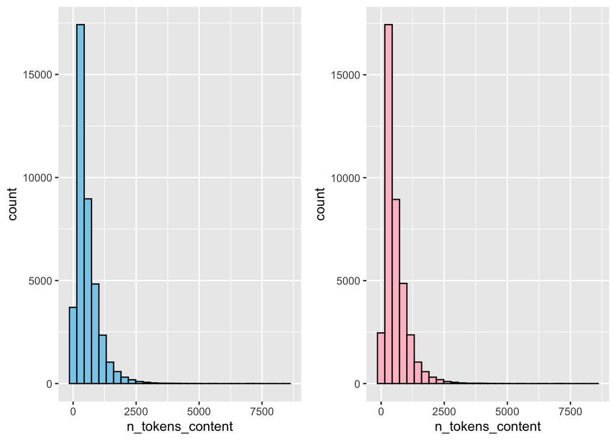

```r
temp_online <- subset(online, n_tokens_content != 0)

beforeRemoving <- ggplot(online, aes(x = n_tokens_content)) +
  geom_histogram(fill = "skyblue", color = "black")

afterRemoving <- ggplot(temp_online, aes(x = n_tokens_content)) +
  geom_histogram(fill = "pink", color = "black")

grid.arrange(beforeRemoving, afterRemoving, nrow=1, ncol=2)
```

```r
online <- temp_online
```

Then, we remove the outliers of the response variable, ‘shares’ variable. The value of ‘shares’ ranges from 1 to 843300, and the histogram shows that the data becomes rarer as the ‘shares’ values increases. Therefore, based on 7500, which is larger than 1.5 times of the IQR, ‘shares’ variable with the value greater than 7500 are removed. If the standard is 1.5 times the IQR, there is too much data to be removed (4523 observations), and it was judged that it is more reasonable to cut the data based on 7500 through the histogram. This is a process for predicting data more accurately. The number of data larger than 7500 is 2995. This accounts for 7.79% of the total data. Also, we can see that there is no number smaller than the lower bound.

```r
summary(data$shares)
```

```
##    Min. 1st Qu.  Median    Mean 3rd Qu.    Max.
##       1     946    1400    3395    2800  843300
```

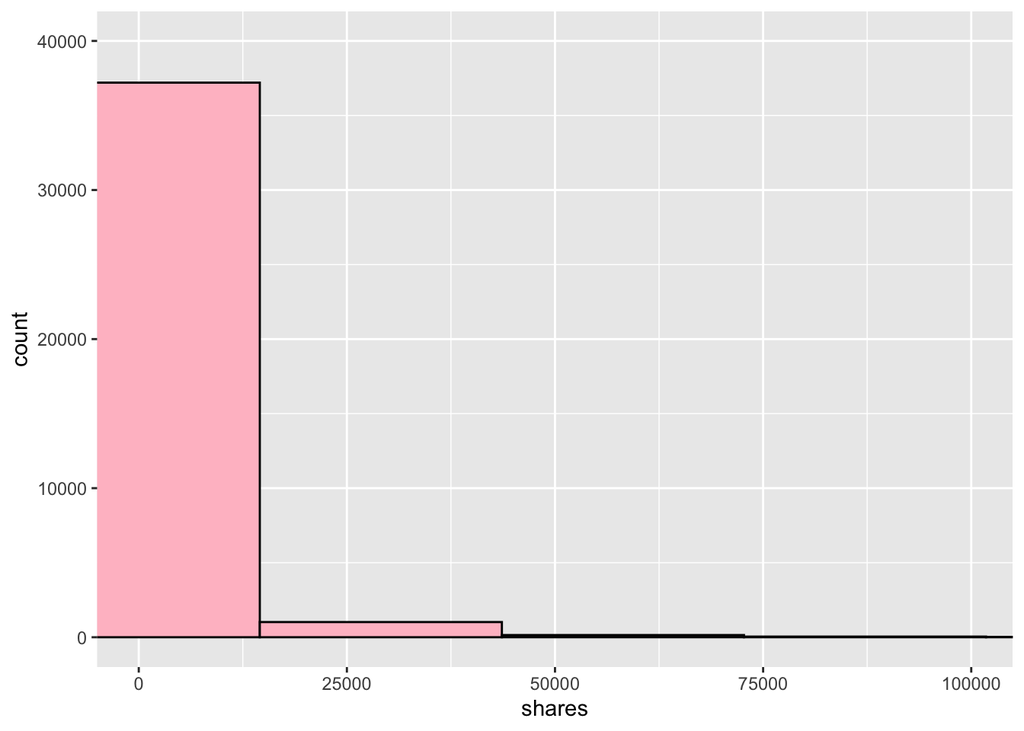

```r
# shares
ggplot(online, aes(x = shares)) +
  geom_histogram(fill = "pink", color = "black") +
  coord_cartesian(xlim = c(0, 100000), ylim = c(0, 40000))
```

```r
Q3 <- fivenum(online$shares)[4]
Q1 = fivenum(online$shares)[2]
IQR <- Q3 - Q1

upperBound <- Q3 + IQR*1.5
lowerBound <- Q1 - IQR*1.5

upperBound
```

```
## [1] 5332.5
```

```r
length(which(online$shares > upperBound))
```

```
## [1] 4523
```

```r
length(which(online$shares > 7500))
```

```
## [1] 2995
```

```r
(length(which(online$shares > 7500))/nrow(online))*100
```

```
## [1] 7.786704
```

```r
length(which(online$shares < lowerBound))
```

```
## [1] 0
```

```r
online <- subset(online, online$shares < 7500)
```

We consider the transformation of predictor and response variables. Some variables are skewed in one direction or their ranges of the values are larger than others. In this case, these variables should be transformed so that the data is spread evenly. Therefore, it is converted into root or log considering the characteristics of the variable. I will show the comparison of histogram before and after transformation.

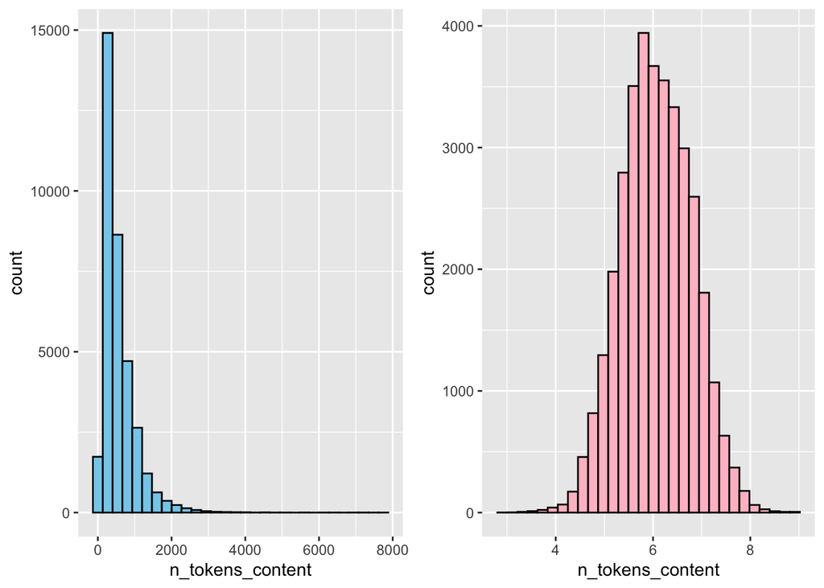

```r
################################ transformation #################################

trans_data <- online

trans_data$n_tokens_content <- log(online$n_tokens_content+1)
trans_data$num_hrefs <- log(online$num_hrefs+1)
trans_data$num_self_hrefs <- log(online$num_self_hrefs+1)
trans_data$num_imgs <- log(online$num_imgs+1)
trans_data$self_reference_min_shares <- log(online$self_reference_min_shares+1)
trans_data$self_reference_max_shares <- log(online$self_reference_max_shares+1)
trans_data$self_reference_avg_sharess <- log(online$self_reference_avg_sharess+1)
trans_data$global_rate_positive_words <- log(online$global_rate_positive_words+1)

beforeTrans <- ggplot(online, aes(x = n_tokens_content)) +
  geom_histogram(fill = "skyblue", color = "black")

afterTrans <- ggplot(trans_data, aes(x = n_tokens_content)) +
  geom_histogram(fill = "pink", color = "black")

grid.arrange(beforeTrans, afterTrans, nrow=1, ncol=2)
```

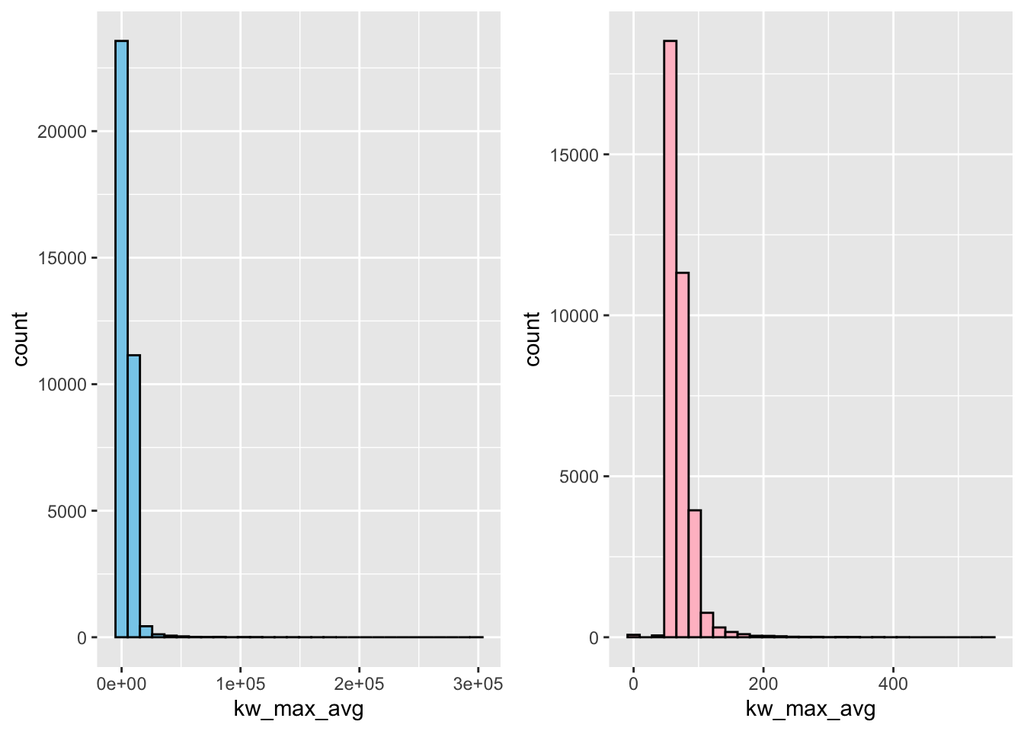

```r
trans_data$kw_max_avg <- sqrt(online$kw_max_avg)
trans_data$kw_avg_avg <- sqrt(online$kw_avg_avg)
trans_data$rate_negative_words <- sqrt(online$rate_negative_words)

beforeTrans <- ggplot(online, aes(x = kw_max_avg)) +
  geom_histogram(fill = "skyblue", color = "black")

afterTrans <- ggplot(trans_data, aes(x = kw_max_avg)) +
  geom_histogram(fill = "pink", color = "black")

grid.arrange(beforeTrans, afterTrans, nrow=1, ncol=2)
```

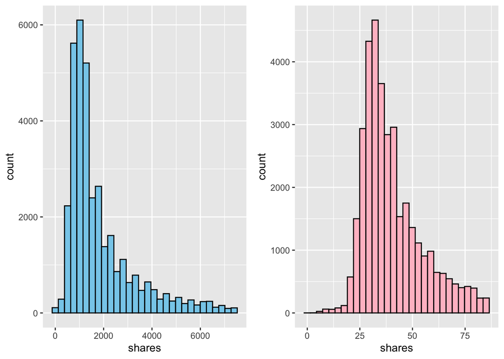

```r
trans_data$shares <- sqrt(online$shares)

beforeTrans <- ggplot(online, aes(x = shares)) +
  geom_histogram(fill = "skyblue", color = "black")

afterTrans <- ggplot(trans_data, aes(x = shares)) +
  geom_histogram(fill = "pink", color = "black")

grid.arrange(beforeTrans, afterTrans, nrow=1, ncol=2)
```

```r
online <- trans_data
```

#### correlation analysis

The number of variables is large, so we need to check whether the variables are correlated by calculating the correlation coefficient. It helps us to confirm the multicollinearity and the consideration of PCA.

```r
cor_online <- online[,-c(1, 4:19, 32:39, 62)]
M <- cor(cor_online)
M
```

```
##                                  timedelta n_tokens_title   kw_min_min
## timedelta                     1.0000000000   -0.234410786  0.587841076
## n_tokens_title               -0.2344107860    1.000000000 -0.106369770
## kw_min_min                    0.5878410765   -0.106369770  1.000000000
## kw_max_min                    0.0324624930   -0.004801422  0.013878733
## kw_avg_min                    0.1469562232   -0.033225271  0.127278795
## kw_min_max                   -0.0696933834    0.009439546 -0.060333492
## kw_max_max                   -0.6402305119    0.118563112 -0.857219616
## kw_avg_max                   -0.4809962509    0.101257305 -0.510872286
## kw_min_avg                   -0.1458397496   -0.006527737 -0.133470168
## kw_max_avg                   -0.0863112491   -0.003112038 -0.116638223
## kw_avg_avg                   -0.1753274018   -0.007525684 -0.210068933
## self_reference_min_shares    -0.1774140144    0.068180331 -0.140489260
## self_reference_max_shares    -0.1715301376    0.072206310 -0.147932162
## self_reference_avg_sharess   -0.1751758723    0.071694399 -0.147761223
## LDA_00                        0.0698676116   -0.070861258  0.024817533
## LDA_01                       -0.0036989968    0.067141719  0.006139918
## LDA_02                       -0.1571133098    0.042420271 -0.078092261
## LDA_03                        0.0114212102    0.032101883  0.010290848
## LDA_04                        0.0821714747   -0.058482532  0.039412297
## global_subjectivity           0.0420692989   -0.035893757  0.011147733
## global_sentiment_polarity     0.1347828694   -0.064947489  0.067520250
## global_rate_positive_words    0.1637480044   -0.051785108  0.084977241
## global_rate_negative_words   -0.0371146597    0.031130855 -0.016994228
## rate_positive_words           0.1359199460   -0.052817713  0.065298386
## rate_negative_words          -0.1368775441    0.051115046 -0.067387495
## avg_positive_polarity         0.0438167937   -0.027093724  0.017560829
## min_positive_polarity         0.0201545214   -0.015052037  0.011679401
## max_positive_polarity         0.0178698272    0.006544563 -0.006256299
## avg_negative_polarity         0.0630667927   -0.035678863  0.036767742
## min_negative_polarity         0.1240280266   -0.050168577  0.068584476
## max_negative_polarity        -0.0333221472    0.005995799 -0.016759787
## title_subjectivity           -0.0140494558    0.083506452 -0.003844416
## title_sentiment_polarity      0.0385278425    0.004003238  0.031182867
## abs_title_subjectivity        0.0113265028   -0.151231289  0.007806294
## abs_title_sentiment_polarity  0.0005640542    0.047696639  0.008652041
## shares                        0.0355425477   -0.042110201  0.038134526
##                                kw_max_min    kw_avg_min    kw_min_max
## timedelta                     0.032462493  0.1469562232 -0.0696933834
## n_tokens_title               -0.004801422 -0.0332252712  0.0094395458
```

[output cut: 537 more lines]

```
## global_rate_positive_words                   0.1285175313  0.078431731
## global_rate_negative_words                   0.0664504123 -0.024153635
## rate_positive_words                          0.0207437575  0.068743474
## rate_negative_words                         -0.0176344881 -0.052311993
## avg_positive_polarity                        0.1404943413  0.033816650
## min_positive_polarity                        0.0162185740 -0.031811842
## max_positive_polarity                        0.1137502041  0.050396892
## avg_negative_polarity                       -0.0918448433 -0.013248621
## min_negative_polarity                       -0.0714053934 -0.013143781
## max_negative_polarity                       -0.0241477878 -0.004444971
## title_subjectivity                           0.7156461632  0.029799719
## title_sentiment_polarity                     0.4098333957  0.050036249
## abs_title_subjectivity                      -0.4148084067  0.003944000
## abs_title_sentiment_polarity                 1.0000000000  0.033778849
## shares                                       0.0337788492  1.000000000
```

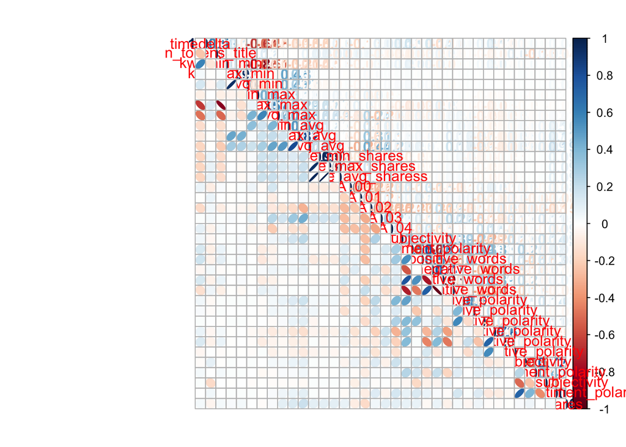

```r
corrplot.mixed(M, upper = "number", lower = "ellipse")
```

## Modeling

PCA is used to predict the number of ‘shares’, based on linear regression models. Because of the problem of too many variables, PCA is used in order to reduce the dimensionality of the data. However, applying with up to PC17 would explain 81% of the variance in this data. This isn’t great, but it’s better than the original 45 variables. Therefore, regression analysis is performed by using this. In addition, since the number of variables is large, the number of variables is reduced by using stepwise regression among the variable selection methods. As a result of the regression analysis, the obtained results is not good, and box-cox transformation and weight least squared (WLS) are applied after confirming that the residuals have non-constant variance.

```r
################################## Modeling ####################################
cont_var <- online[-c(1, 14:19, 32:39, 61, 62)]
factor_var <- online[c(14:19, 32:39, 61)]
# online$shares <- online$shares - 1
# online$shares <- as.numeric(online$shares)
y <- online[c(62)]


### PCA ###
str(cont_var)
```

```
## 'data.frame':    35426 obs. of  45 variables:
##  $ timedelta                   : num  731 731 731 731 731 731 731 731 731 731 ...
##  $ n_tokens_title              : num  12 9 9 9 13 10 8 12 11 10 ...
##  $ n_tokens_content            : num  5.39 5.55 5.36 6.28 6.98 ...
##  $ n_unique_tokens             : num  0.664 0.605 0.575 0.504 0.416 ...
##  $ n_non_stop_words            : num  1 1 1 1 1 ...
##  $ n_non_stop_unique_tokens    : num  0.815 0.792 0.664 0.666 0.541 ...
##  $ num_hrefs                   : num  1.61 1.39 1.39 2.3 3 ...
##  $ num_self_hrefs              : num  1.099 0.693 0.693 0 2.996 ...
##  $ num_imgs                    : num  0.693 0.693 0.693 0.693 3.045 ...
##  $ num_videos                  : num  0 0 0 0 0 0 0 0 0 1 ...
##  $ average_token_length        : num  4.68 4.91 4.39 4.4 4.68 ...
##  $ num_keywords                : num  5 4 6 7 7 9 10 9 7 5 ...
##  $ kw_min_min                  : num  0 0 0 0 0 0 0 0 0 0 ...
##  $ kw_max_min                  : num  0 0 0 0 0 0 0 0 0 0 ...
```

[output cut: 31 more lines]

```r
pca <- prcomp(cont_var, center = TRUE, scale = TRUE)
print(pca)
```

[output not shown]

[output cut: 647 more lines]

[output not shown]

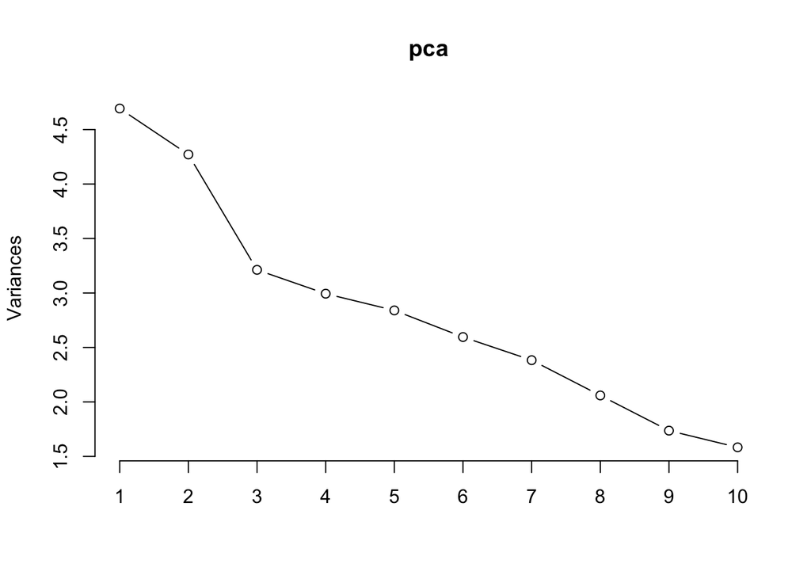

```r
plot(pca, type = 'l')
```

```r
summary(pca)
```

```
## Importance of components:
##                           PC1     PC2     PC3     PC4     PC5     PC6     PC7
## Standard deviation     2.1664 2.06672 1.79231 1.73019 1.68525 1.61110 1.54378
## Proportion of Variance 0.1043 0.09492 0.07139 0.06652 0.06311 0.05768 0.05296
## Cumulative Proportion  0.1043 0.19922 0.27060 0.33713 0.40024 0.45792 0.51088
##                            PC8     PC9    PC10    PC11    PC12    PC13   PC14
## Standard deviation     1.43508 1.31773 1.25825 1.23811 1.13579 1.10118 1.0755
## Proportion of Variance 0.04577 0.03859 0.03518 0.03406 0.02867 0.02695 0.0257
## Cumulative Proportion  0.55665 0.59523 0.63042 0.66448 0.69315 0.72009 0.7458
##                           PC15    PC16    PC17    PC18    PC19   PC20    PC21
## Standard deviation     1.05616 0.97597 0.92564 0.90733 0.86383 0.8271 0.82048
## Proportion of Variance 0.02479 0.02117 0.01904 0.01829 0.01658 0.0152 0.01496
## Cumulative Proportion  0.77059 0.79175 0.81079 0.82909 0.84567 0.8609 0.87583
##                           PC22    PC23    PC24    PC25   PC26    PC27    PC28
## Standard deviation     0.80278 0.78699 0.74825 0.70885 0.6708 0.66490 0.62539
## Proportion of Variance 0.01432 0.01376 0.01244 0.01117 0.0100 0.00982 0.00869
## Cumulative Proportion  0.89015 0.90392 0.91636 0.92752 0.9375 0.94735 0.95604
##                           PC29    PC30    PC31    PC32    PC33    PC34    PC35
## Standard deviation     0.59842 0.51046 0.50537 0.48743 0.47639 0.37274 0.36364
## Proportion of Variance 0.00796 0.00579 0.00568 0.00528 0.00504 0.00309 0.00294
## Cumulative Proportion  0.96400 0.96979 0.97546 0.98074 0.98578 0.98887 0.99181
##                           PC36    PC37    PC38    PC39    PC40    PC41    PC42
## Standard deviation     0.31613 0.27397 0.25818 0.22444 0.21300 0.17278 0.03277
## Proportion of Variance 0.00222 0.00167 0.00148 0.00112 0.00101 0.00066 0.00002
## Cumulative Proportion  0.99403 0.99570 0.99718 0.99830 0.99931 0.99997 1.00000
##                           PC43     PC44      PC45
## Standard deviation     0.01283 0.004826 3.028e-12
## Proportion of Variance 0.00000 0.000000 0.000e+00
## Cumulative Proportion  1.00000 1.000000 1.000e+00
```

```r
pca.matrix <- as.matrix(cont_var) %*% pca$rotation[,1:17]
pca.dat <- data.frame(pca.matrix, factor_var, y)
str(pca.dat)
```

```
## 'data.frame':    35426 obs. of  33 variables:
##  $ PC1                          : num  160 165 160 165 158 ...
##  $ PC2                          : num  -12.53 -8.8 -13.07 -8.73 -14.55 ...
##  $ PC3                          : num  114 118 114 119 113 ...
##  $ PC4                          : num  -18.4 -20 -18.1 -19.9 -17.4 ...
##  $ PC5                          : num  130 125 131 126 134 ...
##  $ PC6                          : num  -181 -178 -181 -177 -180 ...
##  $ PC7                          : num  50 48 49.6 47.3 49.1 ...
##  $ PC8                          : num  -59.6 -61.3 -60.3 -61 -58.9 ...
##  $ PC9                          : num  130 130 130 128 130 ...
##  $ PC10                         : num  -76.2 -77.5 -76.4 -77.2 -76.7 ...
##  $ PC11                         : num  57.9 58.1 57.9 58.3 58.3 ...
##  $ PC12                         : num  -44.4 -46.5 -45.4 -46.7 -45 ...
##  $ PC13                         : num  22.4 23.3 22.2 24.1 22.6 ...
##  $ PC14                         : num  23.4 23.1 24.4 23 22.9 ...
```

[output cut: 19 more lines]

```r
################################################################################
# Model1.
pca.fit1 <- lm(shares ~ ., data = pca.dat)
summary(pca.fit1)
```

```
##
## Call:
## lm(formula = shares ~ ., data = pca.dat)
##
## Residuals:
##     Min      1Q  Median      3Q     Max
## -41.769  -9.159  -3.422   6.125  52.101
##
## Coefficients: (2 not defined because of singularities)
##                                Estimate Std. Error t value Pr(>|t|)
## (Intercept)                    31.94025    1.05197  30.362  < 2e-16 ***
## PC1                            -0.16606    0.14321  -1.160  0.24625
## PC2                            -0.84239    0.18678  -4.510 6.50e-06 ***
## PC3                             0.74471    0.13497   5.518 3.46e-08 ***
## PC4                            -0.08120    0.03079  -2.637  0.00836 **
## PC5                             0.71467    0.06396  11.174  < 2e-16 ***
## PC6                             0.86716    0.11153   7.775 7.74e-15 ***
## PC7                            -0.26249    0.10273  -2.555  0.01062 *
## PC8                            -0.16522    0.17986  -0.919  0.35831
## PC9                             0.23339    0.13127   1.778  0.07543 .
## PC10                            0.69504    0.22693   3.063  0.00219 **
## PC11                            0.34608    0.24994   1.385  0.16616
## PC12                           -0.52184    0.11579  -4.507 6.60e-06 ***
## PC13                            0.18196    0.10195   1.785  0.07430 .
## PC14                            0.75862    0.14608   5.193 2.08e-07 ***
## PC15                            0.54056    0.03664  14.752  < 2e-16 ***
## PC16                            0.05093    0.10056   0.506  0.61254
## PC17                           -0.66249    0.15745  -4.208 2.59e-05 ***
## data_channel_is_lifestyle1     -0.66957    0.48065  -1.393  0.16362
## data_channel_is_entertainment1 -3.82800    0.31290 -12.234  < 2e-16 ***
## data_channel_is_bus1           -2.05644    0.44486  -4.623 3.80e-06 ***
## data_channel_is_socmed1         4.43982    0.44896   9.889  < 2e-16 ***
## data_channel_is_tech1           1.77545    0.43920   4.042 5.30e-05 ***
## data_channel_is_world1         -2.73018    0.44102  -6.191 6.06e-10 ***
## weekday_is_monday1             -5.16792    0.32981 -15.669  < 2e-16 ***
## weekday_is_tuesday1            -5.84017    0.32433 -18.007  < 2e-16 ***
## weekday_is_wednesday1          -5.77030    0.32423 -17.797  < 2e-16 ***
## weekday_is_thursday1           -5.49287    0.32489 -16.907  < 2e-16 ***
## weekday_is_friday1             -4.22809    0.33636 -12.570  < 2e-16 ***
## weekday_is_saturday1           -0.09917    0.40367  -0.246  0.80593
## weekday_is_sunday1                   NA         NA      NA       NA
## is_weekend1                          NA         NA      NA       NA
## LDA_TopicTopic1                -2.46758    0.42676  -5.782 7.44e-09 ***
## LDA_TopicTopic2                -3.85008    0.37406 -10.293  < 2e-16 ***
## LDA_TopicTopic3                -2.93098    0.39703  -7.382 1.59e-13 ***
## LDA_TopicTopic4                -2.03622    0.34631  -5.880 4.15e-09 ***
## ---
## Signif. codes:  0 '***' 0.001 '**' 0.01 '*' 0.05 '.' 0.1 ' ' 1
##
## Residual standard error: 13.55 on 35392 degrees of freedom
## Multiple R-squared:  0.1071, Adjusted R-squared:  0.1063
## F-statistic: 128.6 on 33 and 35392 DF,  p-value: < 2.2e-16
```

```r
# Model2.
pca.step <- step(pca.fit1, data = pca.dat, direction ='both')
```

```
## Start:  AIC=184723
## shares ~ PC1 + PC2 + PC3 + PC4 + PC5 + PC6 + PC7 + PC8 + PC9 +
##     PC10 + PC11 + PC12 + PC13 + PC14 + PC15 + PC16 + PC17 + data_channel_is_lifestyle +
##     data_channel_is_entertainment + data_channel_is_bus + data_channel_is_socmed +
##     data_channel_is_tech + data_channel_is_world + weekday_is_monday +
##     weekday_is_tuesday + weekday_is_wednesday + weekday_is_thursday +
##     weekday_is_friday + weekday_is_saturday + weekday_is_sunday +
##     is_weekend + LDA_Topic
##
##
## Step:  AIC=184723
## shares ~ PC1 + PC2 + PC3 + PC4 + PC5 + PC6 + PC7 + PC8 + PC9 +
##     PC10 + PC11 + PC12 + PC13 + PC14 + PC15 + PC16 + PC17 + data_channel_is_lifestyle +
##     data_channel_is_entertainment + data_channel_is_bus + data_channel_is_socmed +
##     data_channel_is_tech + data_channel_is_world + weekday_is_monday +
##     weekday_is_tuesday + weekday_is_wednesday + weekday_is_thursday +
##     weekday_is_friday + weekday_is_saturday + weekday_is_sunday +
##     LDA_Topic
##
##
## Step:  AIC=184723
## shares ~ PC1 + PC2 + PC3 + PC4 + PC5 + PC6 + PC7 + PC8 + PC9 +
##     PC10 + PC11 + PC12 + PC13 + PC14 + PC15 + PC16 + PC17 + data_channel_is_lifestyle +
##     data_channel_is_entertainment + data_channel_is_bus + data_channel_is_socmed +
##     data_channel_is_tech + data_channel_is_world + weekday_is_monday +
##     weekday_is_tuesday + weekday_is_wednesday + weekday_is_thursday +
##     weekday_is_friday + weekday_is_saturday + LDA_Topic
##
##                                 Df Sum of Sq     RSS    AIC
## - weekday_is_saturday            1        11 6501985 184721
## - PC16                           1        47 6502021 184721
## - PC8                            1       155 6502129 184722
## - PC1                            1       247 6502221 184722
## - PC11                           1       352 6502326 184723
## - data_channel_is_lifestyle      1       357 6502330 184723
## <none>                                       6501974 184723
## - PC9                            1       581 6502554 184724
## - PC13                           1       585 6502559 184724
## - PC7                            1      1199 6503173 184728
## - PC4                            1      1278 6503251 184728
```

[output cut: 215 more lines]

```
## - data_channel_is_world          1      8084 6510787 184759
## - data_channel_is_tech           1      8524 6511226 184761
## - PC12                           1     11573 6514275 184778
## - PC2                            1     15204 6517906 184798
## - LDA_Topic                      4     20575 6523277 184821
## - PC5                            1     25008 6527711 184851
## - data_channel_is_socmed         1     27366 6530068 184864
## - data_channel_is_entertainment  1     29986 6532688 184878
## - PC6                            1     38746 6541448 184925
## - weekday_is_friday              1     41553 6544256 184941
## - PC15                           1     42028 6544730 184943
## - weekday_is_monday              1     66205 6568907 185074
## - weekday_is_thursday            1     78365 6581067 185139
## - weekday_is_wednesday           1     87115 6589817 185186
## - weekday_is_tuesday             1     89176 6591879 185198
```

```r
summary(pca.step)
```

```
##
## Call:
## lm(formula = shares ~ PC2 + PC3 + PC4 + PC5 + PC6 + PC7 + PC9 +
##     PC10 + PC11 + PC12 + PC13 + PC14 + PC15 + PC17 + data_channel_is_entertainment +
##     data_channel_is_bus + data_channel_is_socmed + data_channel_is_tech +
##     data_channel_is_world + weekday_is_monday + weekday_is_tuesday +
##     weekday_is_wednesday + weekday_is_thursday + weekday_is_friday +
##     LDA_Topic, data = pca.dat)
##
## Residuals:
##     Min      1Q  Median      3Q     Max
## -41.904  -9.158  -3.410   6.130  52.028
##
## Coefficients:
##                                Estimate Std. Error t value Pr(>|t|)
## (Intercept)                    31.23086    0.88907  35.127  < 2e-16 ***
## PC2                            -1.00196    0.11014  -9.097  < 2e-16 ***
## PC3                             0.65177    0.09908   6.578 4.83e-11 ***
## PC4                            -0.07076    0.02499  -2.832 0.004630 **
## PC5                             0.67702    0.05803  11.668  < 2e-16 ***
## PC6                             0.96599    0.06652  14.523  < 2e-16 ***
## PC7                            -0.28315    0.08079  -3.505 0.000457 ***
## PC9                             0.32135    0.06590   4.876 1.09e-06 ***
## PC10                            0.63281    0.17902   3.535 0.000409 ***
## PC11                            0.38794    0.23047   1.683 0.092332 .
## PC12                           -0.42981    0.05415  -7.937 2.13e-15 ***
## PC13                            0.24834    0.06772   3.667 0.000246 ***
## PC14                            0.70071    0.13467   5.203 1.97e-07 ***
## PC15                            0.52275    0.03456  15.125  < 2e-16 ***
## PC17                           -0.68299    0.12071  -5.658 1.54e-08 ***
## data_channel_is_entertainment1 -3.66430    0.28681 -12.776  < 2e-16 ***
## data_channel_is_bus1           -1.75757    0.36726  -4.786 1.71e-06 ***
## data_channel_is_socmed1         4.72312    0.38698  12.205  < 2e-16 ***
## data_channel_is_tech1           2.16994    0.31855   6.812 9.79e-12 ***
## data_channel_is_world1         -2.42042    0.36486  -6.634 3.32e-11 ***
## weekday_is_monday1             -5.12012    0.26971 -18.984  < 2e-16 ***
## weekday_is_tuesday1            -5.79074    0.26283 -22.032  < 2e-16 ***
## weekday_is_wednesday1          -5.72252    0.26279 -21.776  < 2e-16 ***
## weekday_is_thursday1           -5.44393    0.26358 -20.654  < 2e-16 ***
## weekday_is_friday1             -4.17717    0.27774 -15.040  < 2e-16 ***
## LDA_TopicTopic1                -2.27325    0.40718  -5.583 2.38e-08 ***
## LDA_TopicTopic2                -3.80717    0.37252 -10.220  < 2e-16 ***
## LDA_TopicTopic3                -2.66627    0.36058  -7.394 1.45e-13 ***
## LDA_TopicTopic4                -2.05773    0.34253  -6.008 1.90e-09 ***
## ---
## Signif. codes:  0 '***' 0.001 '**' 0.01 '*' 0.05 '.' 0.1 ' ' 1
##
## Residual standard error: 13.55 on 35397 degrees of freedom
## Multiple R-squared:  0.107,  Adjusted R-squared:  0.1063
## F-statistic: 151.5 on 28 and 35397 DF,  p-value: < 2.2e-16
```

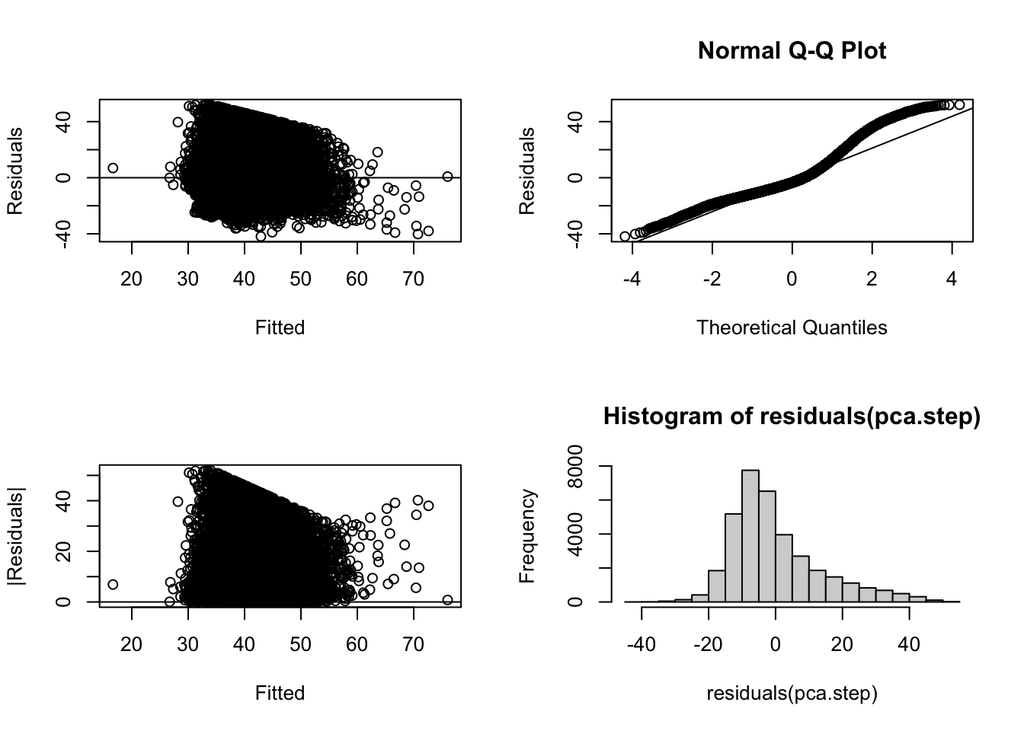

```r
# Residual Plot
par(mfcol = c(2,2))
plot(fitted(pca.step), residuals(pca.step), xlab = 'Fitted', ylab = 'Residuals')
abline(h=0)
plot(fitted(pca.step), abs(residuals(pca.step)), xlab = 'Fitted', ylab = '|Residuals|')
abline(h=0)
qqnorm(residuals(pca.step), ylab = 'Residuals')
qqline(residuals(pca.step))
hist(residuals(pca.step))
```

```r
# Model3. WLS
resid <- residuals(pca.step)
absresid <- abs(resid)

lmfitw0 <- lm(absresid ~ PC2 + PC3 + PC4 + PC5 + PC6 + PC7 + PC9 +
                PC10 + PC11 + PC12 + PC13 + PC14 + PC15 + PC17 + data_channel_is_entertainment +
                data_channel_is_bus + data_channel_is_socmed + data_channel_is_tech +
                data_channel_is_world + weekday_is_monday + weekday_is_tuesday +
                weekday_is_wednesday + weekday_is_thursday + weekday_is_friday +
                LDA_Topic, data = pca.dat)

w <- 1/fitted(lmfitw0)^2

wlm <- lm(shares ~ PC2 + PC3 + PC4 + PC5 + PC6 + PC7 + PC9 +
            PC10 + PC11 + PC12 + PC13 + PC14 + PC15 + PC17 + data_channel_is_entertainment +
            data_channel_is_bus + data_channel_is_socmed + data_channel_is_tech +
            data_channel_is_world + weekday_is_monday + weekday_is_tuesday +
            weekday_is_wednesday + weekday_is_thursday + weekday_is_friday +
            LDA_Topic, weights = w, data = pca.dat)
summary(wlm)
```

```
##
## Call:
## lm(formula = shares ~ PC2 + PC3 + PC4 + PC5 + PC6 + PC7 + PC9 +
##     PC10 + PC11 + PC12 + PC13 + PC14 + PC15 + PC17 + data_channel_is_entertainment +
##     data_channel_is_bus + data_channel_is_socmed + data_channel_is_tech +
##     data_channel_is_world + weekday_is_monday + weekday_is_tuesday +
##     weekday_is_wednesday + weekday_is_thursday + weekday_is_friday +
##     LDA_Topic, data = pca.dat, weights = w)
##
## Weighted Residuals:
##     Min      1Q  Median      3Q     Max
## -4.3024 -0.8972 -0.3382  0.6008  6.9353
##
## Coefficients:
##                                Estimate Std. Error t value Pr(>|t|)
## (Intercept)                    27.85360    0.91741  30.361  < 2e-16 ***
## PC2                            -1.07420    0.10938  -9.820  < 2e-16 ***
## PC3                             0.67911    0.09715   6.991 2.79e-12 ***
## PC4                            -0.09136    0.02308  -3.958 7.56e-05 ***
## PC5                             0.62409    0.05752  10.851  < 2e-16 ***
## PC6                             0.94800    0.06515  14.551  < 2e-16 ***
## PC7                            -0.21209    0.08092  -2.621 0.008769 **
## PC9                             0.46050    0.06598   6.979 3.02e-12 ***
## PC10                            1.30597    0.18656   7.000 2.60e-12 ***
## PC11                            0.84247    0.23274   3.620 0.000295 ***
## PC12                           -0.52679    0.05452  -9.662  < 2e-16 ***
## PC13                            0.40412    0.06919   5.841 5.25e-09 ***
## PC14                            0.52774    0.13350   3.953 7.73e-05 ***
## PC15                            0.58610    0.03556  16.480  < 2e-16 ***
## PC17                           -0.59930    0.11898  -5.037 4.75e-07 ***
## data_channel_is_entertainment1 -3.40940    0.30036 -11.351  < 2e-16 ***
## data_channel_is_bus1           -1.54763    0.38042  -4.068 4.75e-05 ***
## data_channel_is_socmed1         4.88155    0.41296  11.821  < 2e-16 ***
## data_channel_is_tech1           2.46485    0.33888   7.274 3.57e-13 ***
## data_channel_is_world1         -2.24792    0.36188  -6.212 5.30e-10 ***
## weekday_is_monday1             -5.02953    0.26690 -18.844  < 2e-16 ***
## weekday_is_tuesday1            -5.79840    0.25835 -22.444  < 2e-16 ***
## weekday_is_wednesday1          -5.73317    0.25895 -22.140  < 2e-16 ***
## weekday_is_thursday1           -5.52294    0.26029 -21.218  < 2e-16 ***
## weekday_is_friday1             -4.16111    0.27296 -15.244  < 2e-16 ***
## LDA_TopicTopic1                -2.32870    0.40261  -5.784 7.36e-09 ***
## LDA_TopicTopic2                -3.47531    0.35796  -9.709  < 2e-16 ***
## LDA_TopicTopic3                -2.76638    0.37169  -7.443 1.01e-13 ***
## LDA_TopicTopic4                -1.84149    0.34248  -5.377 7.63e-08 ***
## ---
## Signif. codes:  0 '***' 0.001 '**' 0.01 '*' 0.05 '.' 0.1 ' ' 1
##
## Residual standard error: 1.304 on 35397 degrees of freedom
## Multiple R-squared:  0.1341, Adjusted R-squared:  0.1334
## F-statistic: 195.7 on 28 and 35397 DF,  p-value: < 2.2e-16
```

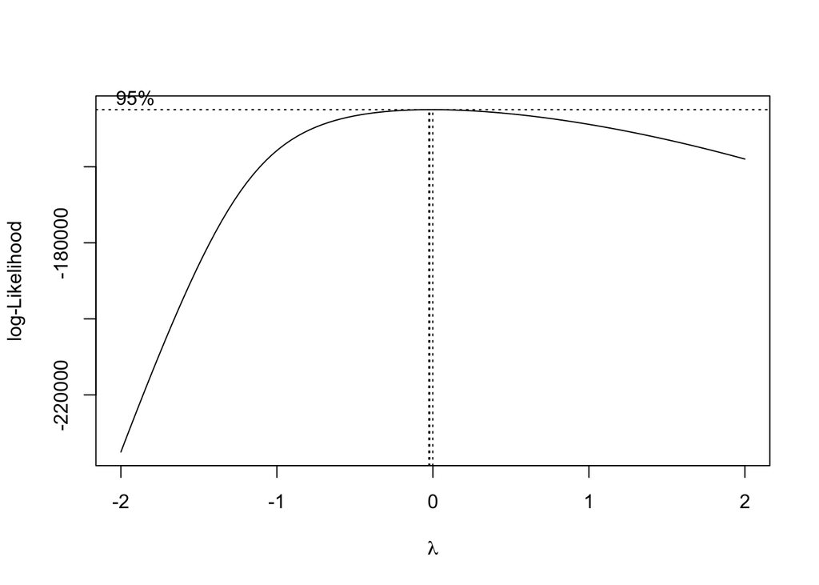

```r
# Model4. Box-cox
par(mfcol=c(1,1))
bc <- boxcox(pca.step, plotit = TRUE, lambda = seq(-2, 2, by = 0.1))
```

```r
lam <- bc$x[which.max(bc$y)]
ytran <- (pca.dat$shares^lam-1)/lam
boxcox.fit <- lm(ytran ~ PC2 + PC3 + PC4 + PC5 + PC6 + PC7 + PC9 +
                   PC10 + PC11 + PC12 + PC13 + PC14 + PC15 + PC17 + data_channel_is_entertainment +
                   data_channel_is_bus + data_channel_is_socmed + data_channel_is_tech +
                   data_channel_is_world + weekday_is_monday + weekday_is_tuesday +
                   weekday_is_wednesday + weekday_is_thursday + weekday_is_friday +
                   LDA_Topic, data = pca.dat)
summary(boxcox.fit)
```

```
##
## Call:
## lm(formula = ytran ~ PC2 + PC3 + PC4 + PC5 + PC6 + PC7 + PC9 +
##     PC10 + PC11 + PC12 + PC13 + PC14 + PC15 + PC17 + data_channel_is_entertainment +
##     data_channel_is_bus + data_channel_is_socmed + data_channel_is_tech +
##     data_channel_is_world + weekday_is_monday + weekday_is_tuesday +
##     weekday_is_wednesday + weekday_is_thursday + weekday_is_friday +
##     LDA_Topic, data = pca.dat)
##
## Residuals:
##     Min      1Q  Median      3Q     Max
## -3.5672 -0.1942 -0.0369  0.1795  0.9423
##
## Coefficients:
##                                  Estimate Std. Error t value Pr(>|t|)
## (Intercept)                     3.3082824  0.0193991 170.538  < 2e-16 ***
## PC2                            -0.0204935  0.0024031  -8.528  < 2e-16 ***
## PC3                             0.0113553  0.0021619   5.252 1.51e-07 ***
## PC4                            -0.0006067  0.0005452  -1.113   0.2658
## PC5                             0.0158383  0.0012661  12.510  < 2e-16 ***
## PC6                             0.0214188  0.0014513  14.758  < 2e-16 ***
## PC7                            -0.0084007  0.0017627  -4.766 1.89e-06 ***
## PC9                             0.0097797  0.0014379   6.801 1.05e-11 ***
## PC10                            0.0154885  0.0039061   3.965 7.35e-05 ***
## PC11                            0.0105810  0.0050287   2.104   0.0354 *
## PC12                           -0.0093634  0.0011816  -7.925 2.35e-15 ***
## PC13                            0.0074164  0.0014776   5.019 5.21e-07 ***
## PC14                            0.0145212  0.0029385   4.942 7.78e-07 ***
## PC15                            0.0112729  0.0007541  14.949  < 2e-16 ***
## PC17                           -0.0146218  0.0026338  -5.552 2.85e-08 ***
## data_channel_is_entertainment1 -0.0826968  0.0062581 -13.214  < 2e-16 ***
## data_channel_is_bus1           -0.0314936  0.0080135  -3.930 8.51e-05 ***
## data_channel_is_socmed1         0.1096180  0.0084437  12.982  < 2e-16 ***
## data_channel_is_tech1           0.0555754  0.0069507   7.996 1.33e-15 ***
## data_channel_is_world1         -0.0549895  0.0079611  -6.907 5.02e-12 ***
## weekday_is_monday1             -0.1217845  0.0058849 -20.694  < 2e-16 ***
## weekday_is_tuesday1            -0.1362582  0.0057348 -23.760  < 2e-16 ***
## weekday_is_wednesday1          -0.1356432  0.0057339 -23.656  < 2e-16 ***
## weekday_is_thursday1           -0.1291264  0.0057512 -22.452  < 2e-16 ***
## weekday_is_friday1             -0.0962155  0.0060602 -15.877  < 2e-16 ***
## LDA_TopicTopic1                -0.0520181  0.0088844  -5.855 4.81e-09 ***
## LDA_TopicTopic2                -0.0867209  0.0081281 -10.669  < 2e-16 ***
## LDA_TopicTopic3                -0.0587247  0.0078677  -7.464 8.58e-14 ***
## LDA_TopicTopic4                -0.0429652  0.0074737  -5.749 9.06e-09 ***
## ---
## Signif. codes:  0 '***' 0.001 '**' 0.01 '*' 0.05 '.' 0.1 ' ' 1
##
## Residual standard error: 0.2957 on 35397 degrees of freedom
## Multiple R-squared:  0.1192, Adjusted R-squared:  0.1185
## F-statistic:   171 on 28 and 35397 DF,  p-value: < 2.2e-16
```

## Evaluation - Discussion of what you saw/did

Validation is performed based on these three models. The train data and test data are divided 7 into 3 and proceeded 100 times to calculate AIC, BIC, and prediction accuracy, which is similar with mean of the error. As a result of this validation, I can figure out that the model with box-cox transformation has the smallest values of AIC, BIC, and prediction accuracy. It means that it is the best model among them. Nevertheless, it need to think of that the data is insufficient to predict the number of ‘shares’, and it is necessary to apply various models suitable for high-dimensional data.

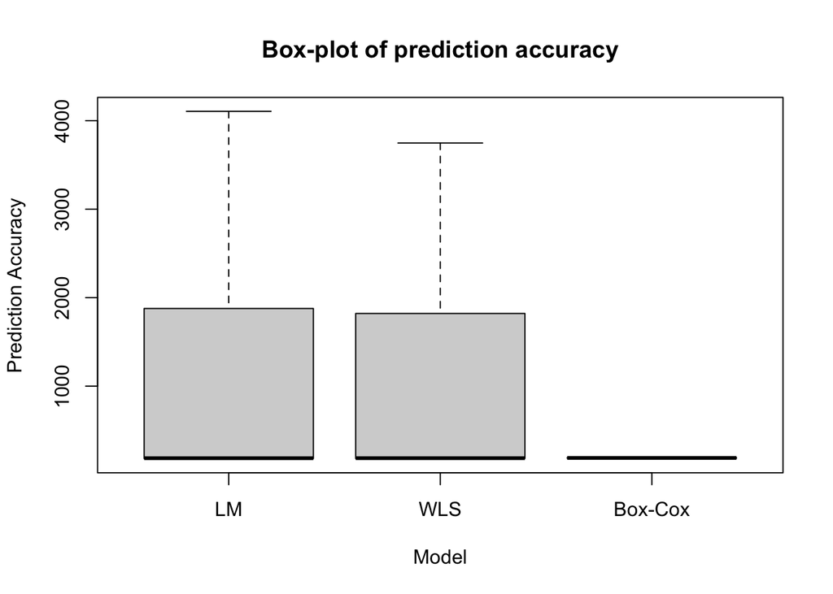

```r
set.seed(1234)
acc.result <- matrix(NA, 3, 100)
AIC.result <- matrix(NA, 3, 100)
BIC.result <- matrix(NA, 3, 100)

for (i in 1:100) {
  tt <- sample(nrow(pca.dat), round(nrow(pca.dat)*0.7, 0), replace=FALSE)
  train.set <- pca.dat[tt,]
  test.set <- pca.dat[-tt,]

  # model1.
  lm.fit <- lm(shares ~ PC2 + PC3 + PC4 + PC5 + PC6 + PC7 + PC9 +
                 PC10 + PC11 + PC12 + PC13 + PC14 + PC15 + PC17 + data_channel_is_entertainment +
                 data_channel_is_bus + data_channel_is_socmed + data_channel_is_tech +
                 data_channel_is_world + weekday_is_monday + weekday_is_tuesday +
                 weekday_is_wednesday + weekday_is_thursday + weekday_is_friday +
                 LDA_Topic, data = train.set)

  # model2.
  resid <- residuals(lm.fit)
  absresid <- abs(resid)
  lmfitw0 <- lm(absresid ~ PC2 + PC3 + PC4 + PC5 + PC6 + PC7 + PC9 +
                  PC10 + PC11 + PC12 + PC13 + PC14 + PC15 + PC17 + data_channel_is_entertainment +
                  data_channel_is_bus + data_channel_is_socmed + data_channel_is_tech +
                  data_channel_is_world + weekday_is_monday + weekday_is_tuesday +
                  weekday_is_wednesday + weekday_is_thursday + weekday_is_friday +
                  LDA_Topic, data = train.set)
  w <- 1/fitted(lmfitw0)^2
  wlm <- lm(shares ~ PC2 + PC3 + PC4 + PC5 + PC6 + PC7 + PC9 +
              PC10 + PC11 + PC12 + PC13 + PC14 + PC15 + PC17 + data_channel_is_entertainment +
              data_channel_is_bus + data_channel_is_socmed + data_channel_is_tech +
              data_channel_is_world + weekday_is_monday + weekday_is_tuesday +
              weekday_is_wednesday + weekday_is_thursday + weekday_is_friday +
              LDA_Topic, weights = w, data = train.set)

  # Model3. Box-cox
  bc <- boxcox(lm.fit, plotit = FALSE, lambda = seq(-2, 2, by = 0.1))
  lam <- bc$x[which.max(bc$y)]
  if (lam == 0) {
    ytran <- log(train.set$shares)
  } else {
    ytran <- (train.set$shares^lam-1)/lam
  }
  boxcox.fit <- lm(ytran ~ PC1 + PC2 + PC3 + PC4 + PC5 + PC6 + PC7 + PC8 + PC10 +
                     PC12 + PC14 + PC15 + PC17 + data_channel_is_lifestyle + data_channel_is_entertainment +
                     data_channel_is_bus + data_channel_is_socmed + data_channel_is_tech +
                     data_channel_is_world + weekday_is_monday + weekday_is_tuesday +
                     weekday_is_wednesday + weekday_is_thursday + weekday_is_friday +
                     LDA_Topic, data = train.set)

  acc.result[1, i] <- round(mean((test.set$shares - predict(lm.fit, test.set))^2), 4)
  acc.result[2, i] <- round(mean((test.set$shares - predict(wlm, test.set))^2), 4)
  if (lam == 0) {
    trans.pred <- exp(predict(boxcox.fit, test.set))
  } else {
    trans.pred <- (predict(boxcox.fit, test.set)*lam+1)^(1/lam)
  }
  acc.result[3, i] <- round(mean((test.set$shares - trans.pred)^2), 4)

  AIC.result[1, i] <-  AIC(lm.fit, wlm, boxcox.fit)[1, 2]
  AIC.result[2, i] <-  AIC(lm.fit, wlm, boxcox.fit)[2, 2]
  AIC.result[3, i] <-  AIC(lm.fit, wlm, boxcox.fit)[3, 2]

  BIC.result[1, i] <-  BIC(lm.fit, wlm, boxcox.fit)[1, 2]
  BIC.result[2, i] <-  BIC(lm.fit, wlm, boxcox.fit)[2, 2]
  BIC.result[3, i] <-  BIC(lm.fit, wlm, boxcox.fit)[3, 2]
}

acc <- data.frame(t(acc.result))
par(mfcol = c(1, 1))
boxplot(acc, xlab = 'Model', ylab = "Prediction Accuracy", names=c("LM", "WLS", "Box-Cox"), main = 'Box-plot of prediction accuracy')
```

```r
apply(acc.result, 1, mean)
```

```
## [1] 875.9075 860.0574 188.4526
```

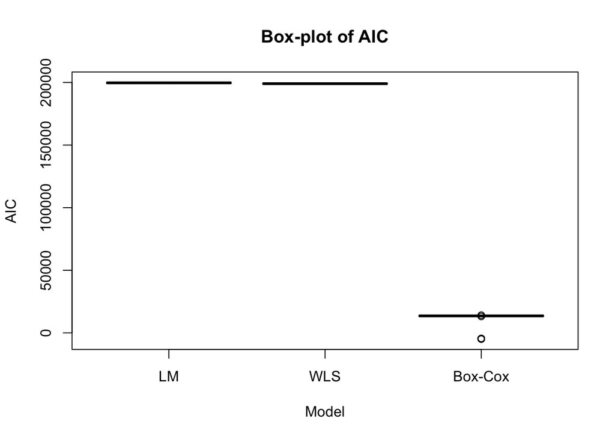

```r
AIC <- data.frame(t(AIC.result))
par(mfcol = c(1, 1))
boxplot(AIC, xlab = 'Model', ylab = "AIC", names=c("LM", "WLS", "Box-Cox"), main = 'Box-plot of AIC')
```

```r
apply(AIC.result, 1, mean)
```

```
## [1] 199692.95 199054.33  11989.48
```

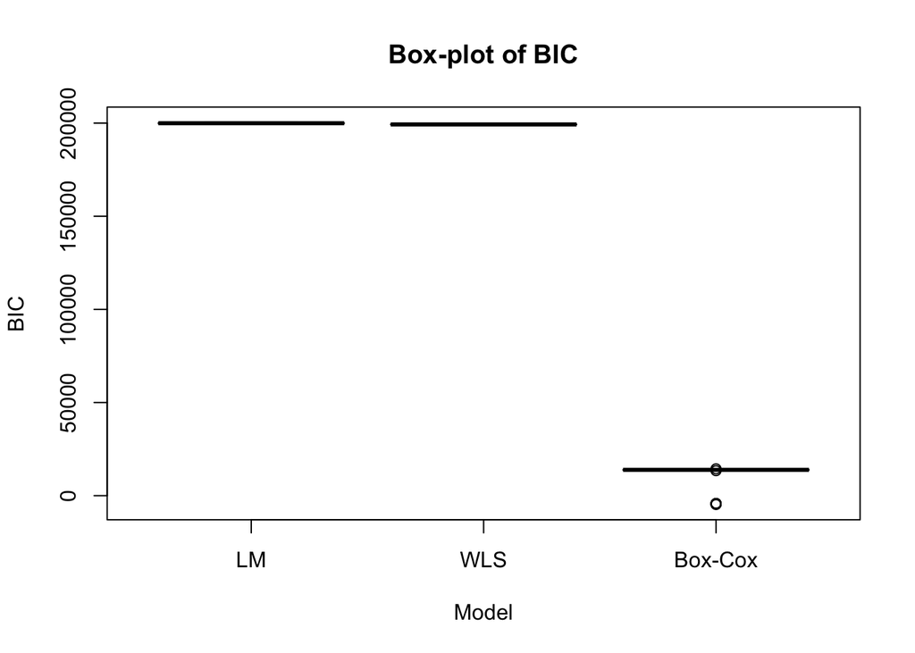

```r
BIC <- data.frame(t(BIC.result))
par(mfcol = c(1, 1))
boxplot(BIC, xlab = 'Model', ylab = "BIC", names=c("LM", "WLS", "Box-Cox"), main = 'Box-plot of BIC')
```

```r
apply(BIC.result, 1, mean)
```

```
## [1] 199936.51 199297.88  12233.03
```